# 언어심리학을 위한 데이터 사이언스 5주차: 데이터 사이언스 #3 (데이터 시각화)

### 2) 각종 논항을 통해 레이어 개선해나가기

- 지오메트리 함수는 `aes`나 `data` 말고도 다양한 논항을 보유하고 있음. 그리고 특정 지오메트리 함수마다 해당 함수에만 사용되는 고유한 논항들이 존재.
- 미학적 맵핑(`aes` 함수) 밖에 있는 논항
  - `size` 논항
    - 기존 플롯은 포인트의 크기를 따로 정의하지 않았기 때문에 디폴트 크기로 구현됨. `size` 논항을 이용하면 포인트의 크기를 바꿀 수 있음
    - `size`는 `aes()` 함수 내에 들어 있지 않으므로 미학적 맵핑이 아님. 미학적 맵핑은 데이터 내의 특정한 관찰값들([EX] 데이터의 특정 열)을 특정한 시각적 자질에 대응시키는 것임.
    - 아래 코드에서 `size`는 2010년 미국 총기살인 데이터의 특정 열 관찰값 포인트의 크기가 아닌 전체적인 관찰값 포인트의 크기를 정의하고 있음.

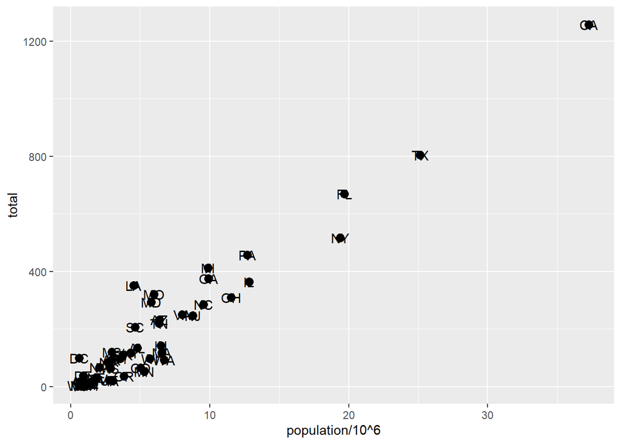

```r
# size 논항을 통해 포인트의 크기를 3으로 설정.
p + geom_point(aes(population/10^6, total), size = 3) +
  geom_text(aes(population/10^6, total, label = abb))
```

- `nudge_x` 논항
  - 포인트가 크고 레이블 바로 위에 있어서 레이블을 가림. `geom_text`의 논항 중 하나인 `nudge_x`를 사용하면, 포인트와 레이블의 간격을 띄울 수 있음.
  - 그래도 여전히 대부분의 포인트가 한데 뭉쳐 있어 가시성이 떨어짐.

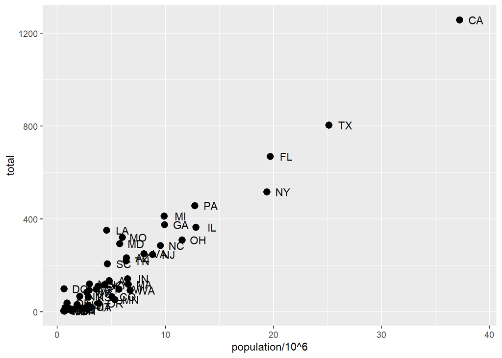

```r
# nudge_x 논항을 통해 포인트와 레이블의 간격을 설정.
p + geom_point(aes(population/10^6, total), size = 3) +
  geom_text(aes(population/10^6, total, label = abb), nudge_x = 1.5)
```

## (7) 전역적(global) 맵핑 vs. 지역적(local) 맵핑

- 전역적 맵핑
  - 상기 코드에서 지오메트리 레이어마다 `aes(population/10^6, total)` 맵핑을 반복해주었음. 그러나 전역적인 미학적 맵핑을 사용하면 불필요한 반복을 피할 수 있음.
  - 설명: `ggplot` 함수 내에서 맵핑을 정의하면, 레이어에 추가되는 모든 지오메트리가 이 맵핑을 따르게 됨.
  - 예시: 포인트의 크기와 포인트-레이블의 간격만 바꾸고자 할 경우, `size`와 `nudge_x` 논항을 각각 `geom_point` 지오메트리 함수와 `geom_text` 지오메트리 함수에 포함시키면 됨.

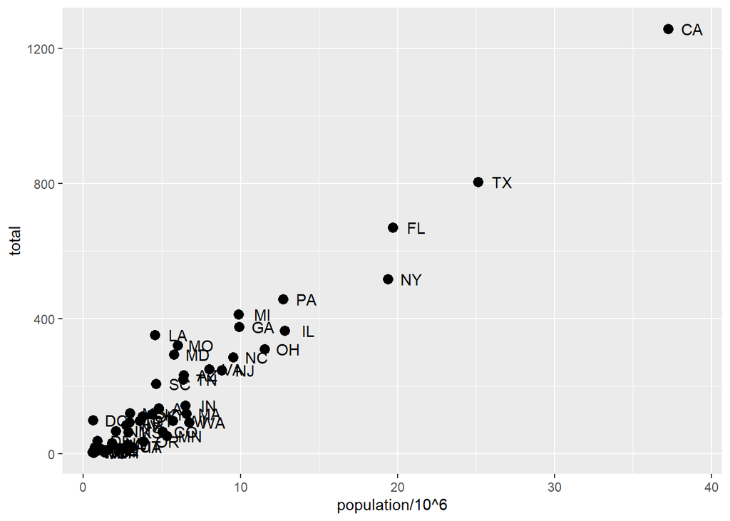

```r
# ggplot 객체 p 정의하기.
p <- murders %>%
  ggplot(aes(population/10^6, total, label = abb))

# 전역적 맵핑을 통해 geom_point와 geom_text 레이어에 size, nudge_x 논항 넣기.
p + geom_point(size = 3) +
  geom_text(nudge_x = 1.5)
```

- 지역적 맵핑
  - 설명:`aes` 함수 안에서 논항을 정의하면, 해당 레이어의 지오메트리에서만 이 맵핑을 따르게 됨.
  - 기능: 각각의 레이어마다 새로운 지역적 맵핑으로 전역적 맵핑을 덮어쓸 수 있음.
  - 예시: `geom_text` 레이어의 미학적 맵핑에 대해 레이블을 따로 정의하고자 한다면, `geom_text`의 `aes` 함수 내에서 `label` 논항을 정의해주면 됨.

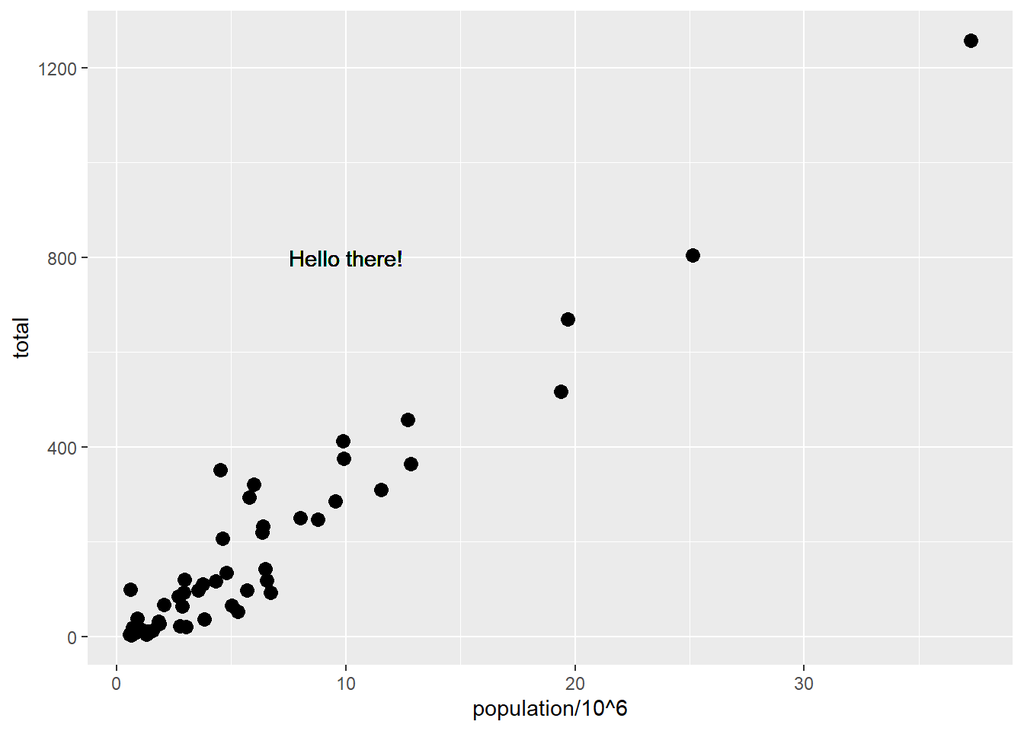

```r
# ggplot 객체 p 정의하기.
p + geom_point(size = 3) +
  geom_text(aes(x = 10, y = 800, label = "Hello there!")) # x축 = 10 & y축 = 800의 위치에 "Hello there!"라는 레이블을 달아라!
```